# TCGA Survival Analysis

## Intro

Gene expression data allows us to gain a snapshot of the cellular state in diseased tissue and is increasingly been used in stratified/personalised medicine approaches.

We’ll be using RNA-sequencing data from cancer patients to demonstrate the principals of stratified medicine. The TGCA datasets provide a number of expression datasets with corresponding clinical data.

In this tutorial we’ll be using the R MarkDown notebooks to record our code and present the results. When you execute code within the notebook, the results appear beneath the code. Try executing the first chunk by clicking the *Run* button within the chunk or by placing your cursor inside it and pressing *Ctrl+Shift+Enter*. Add a new chunk by clicking the *Insert Chunk* button on the toolbar or by pressing *Ctrl+Alt+I*. When you save the notebook, an HTML file containing the code and output will be saved alongside it (click the *Preview* button or press *Ctrl+Shift+K* to preview the HTML file).

## Analysis

In this example we’ll download expression data and clinical data for BRCA (breast invasive carcinoma).

Load the expression data and have a look at it.

```r
#load the libraries
library(survival)
library(limma)
library(DT)
library(survminer)
#read the expression data table - normalised RNA-seq counts for each gene+patient
expressionDataPath<-"gdac.broadinstitute.org_BRCA.Merge_rnaseqv2__illuminahiseq_rnaseqv2__unc_edu__Level_3__RSEM_genes_normalized__data.Level_3.2016012800.0.0/BRCA.rnaseqv2__illuminahiseq_rnaseqv2__unc_edu__Level_3__RSEM_genes_normalized__data.data.txt"
rna <- read.delim(expressionDataPath, header=T, sep="\t",row.names = 1)
rna<-rna[-1,]
x<-rna
rna<- t(apply(rna,1,as.numeric))
colnames(rna)<-colnames(x)
#look at the structure of the table
str(rna)
```

```
 num [1:20531, 1:1212] 0 16.4 12.9 52.2 408.1 ...
 - attr(*, "dimnames")=List of 2
  ..$ : chr [1:20531] "?|100130426" "?|100133144" "?|100134869" "?|10357" ...
  ..$ : chr [1:1212] "TCGA.3C.AAAU.01A.11R.A41B.07" "TCGA.3C.AALI.01A.11R.A41B.07" "TCGA.3C.AALJ.01A.31R.A41B.07" "TCGA.3C.AALK.01A.11R.A41B.07" ...
```

```r
#what are the dimensions of the table?
dim(rna)
```

```
[1] 20531  1212
```

```r
#look at the first few rows and columns
rna[1:3,1:3]
```

```
            TCGA.3C.AAAU.01A.11R.A41B.07 TCGA.3C.AALI.01A.11R.A41B.07 TCGA.3C.AALJ.01A.31R.A41B.07
?|100130426                       0.0000                       0.0000                       0.9066
?|100133144                      16.3644                       9.2659                      11.6228
?|100134869                      12.9316                      17.3790                       9.2294
```

Remove the genes with more than 50% missing values

```r
#function to remove the samples with more than 50% missing values
removeLowExpGenes<-function(rna){
  numZeroCountSamples <- apply(rna,1,function(i) sum(i == 0))
  toRemove <- which(numZeroCountSamples > ncol(rna)/2)
  rna <- rna[-toRemove,]
  return(rna)
}
rna.filt<-removeLowExpGenes(rna)
#size of the filtered dataframe
dim(rna.filt)
```

```
[1] 17675  1212
```

RNA-seq is not normally distributed so we need to variance stabilise the data. We can then calculate z-scores relative to the normal samples to give for each patient an indicator if a gene is under/over expressed

```r
#function to variance stabilise the data
varianceStabilise<-function(expData,t_index){

  # define the linear model
  cond <- factor(ifelse(seq(1, dim(expData)[2],1) %in% t_index, 1,  0))
  d <- model.matrix(~1 + cond)

  #variance normalise the data
  x <- t(apply(expData, 1, as.numeric))
  expData_vm <- voom(x, d, plot=FALSE)$E
  colnames(expData_vm) <- gsub("\\.","-",substr(colnames(expData),1,12))
  return(expData_vm)
}
#function to z-score the data relative to the normal samples
zScoreScale<-function(expData,n_index,t_index){
  #control stats
  mean_n <- rowMeans(expData[, n_index])
  sd_n <- apply(expData[, n_index], 1, sd)

  #calculate the z-scores
  tumor <- expData[,t_index]
  z_expData<-t(sapply(1:nrow(tumor),function(x) (tumor[x,]-mean_n[x])/sd_n[x]))
  rownames(z_expData) <- sapply(rownames(expData), function(x) unlist(strsplit(x,"\\|"))[[1]])
    return(z_expData)
}
# get the indexes of the normal/control samples
n_index <- which(substr(colnames(rna.filt),14,14) == "1")
t_index <- which(substr(colnames(rna.filt),14,14) == "0")
#variance stabilise the data
rna.vst<-varianceStabilise(rna.filt,t_index)
#z-score scale the data
rna.zscore<-zScoreScale(rna.vst,n_index,t_index)
```

We wish to see if features in the gene expression data are useful in distinguishing between patient survival time. We have a missing data problem where patient death is not observed, but the date of the last followup is known. This means we can’t use this patient after this follow-up date in the calculation since we don’t known if the patient has died (right censored).

```r
#load the clinical data
clincialDataPath<-"gdac.broadinstitute.org_BRCA.Clinical_Pick_Tier1.Level_4.2016012800.0.0/BRCA.clin.merged.picked.txt"
clinicalData <- read.delim(clincialDataPath,sep="\t",stringsAsFactors = F)
rownames(clinicalData)<-clinicalData[,1]
clinicalData<-clinicalData[,-1]
clinicalData<-as.data.frame(t(clinicalData))
#what does it look like
head(clinicalData)
```

|  | Composite Element REF | years_to_birth | vital_status | days_to_death | days_to_last_followup | tumor_tissue_site | pathologic_stage | pathology_T_stage | pathology_N_stage | pathology_M_stage | gender | date_of_initial_pathologic_diagnosis | days_to_last_known_alive | radiation_therapy | histological_type | number_of_lymph_nodes | race | ethnicity |
| --- | --- | --- | --- | --- | --- | --- | --- | --- | --- | --- | --- | --- | --- | --- | --- | --- | --- | --- |
| tcga.5l.aat0 | value | 42 | 0 | NA | 1477 | breast | stage iia | t2 | n0 | m0 | female | 2010 | NA | yes | infiltrating lobular carcinoma | 0 | white | hispanic or latino |
| tcga.5l.aat1 | value | 63 | 0 | NA | 1471 | breast | stage iv | t2 | n0 | m1 | female | 2010 | NA | no | infiltrating lobular carcinoma | 0 | white | hispanic or latino |
| tcga.a1.a0sp | value | 40 | 0 | NA | 584 | breast | stage iia | t2 | n0 (i-) | m0 | female | 2007 | NA | NA | infiltrating ductal carcinoma | 0 | NA | not hispanic or latino |
| tcga.a2.a04v | value | 39 | 1 | 1920 | NA | breast | stage iia | t2 | n0 (i-) | m0 | female | 2005 | NA | no | infiltrating ductal carcinoma | 0 | white | not hispanic or latino |
| tcga.a2.a04y | value | 53 | 0 | NA | 1099 | breast | stage iib | t2 | n1mi | m0 | female | 2008 | NA | yes | infiltrating ductal carcinoma | 1 | white | NA |
| tcga.a2.a0cq | value | 62 | 0 | NA | 2695 | breast | stage ia | t1 | n0 (i-) | m0 | female | 2003 | NA | yes | infiltrating ductal carcinoma | 0 | black or african american | not hispanic or latino |

We need to combine the days_to_death and days_to_last_followup columns to censor by the vital_status column

```r
#function to process the clinical data
processClinical<-function(all_clin){

  # create vector time to death containing the values for days_to_death or days_to_last_followup to censor
  all_clin$new_death <- c()
  for (i in 1:length(as.numeric(as.character(all_clin$days_to_death)))){
    all_clin$new_death[i] <- ifelse(is.na(as.numeric(as.character(all_clin$days_to_death))[i]),
                                    as.numeric(as.character(all_clin$days_to_last_followup))[i],as.numeric(as.character(all_clin$days_to_death))[i])
  }

  #get the IDs to match the expData IDs
  IDS<-gsub(pattern = ".",replacement = "-",x = rownames(all_clin),fixed = T)
  IDS<-toupper(IDS)
  rownames(all_clin)<-IDS

  return(all_clin)

}
clinicalData<-processClinical(clinicalData)
# death censor variable
clinicalData$death_event <- ifelse(clinicalData$vital_status == "alive", 0, 1)
```

match up the expression and the clinical data for statistical analysis

```r
# create event vector for RNASeq data
# where signficantly differentially enriched gene > 1.96 zscore
event_rna <- t(apply(rna.zscore, 1, function(x) ifelse(abs(x) >= 1.96,1,0)))
# indices for matched samples
ind_tum <- which(unique(colnames(rna.zscore)) %in% rownames(clinicalData))
ind_clin <- which(rownames(clinicalData) %in% colnames(rna.zscore))
#reorder the data to match
clinicalData<-clinicalData[ind_clin ,]
event_rna<- event_rna[, ind_tum]
```

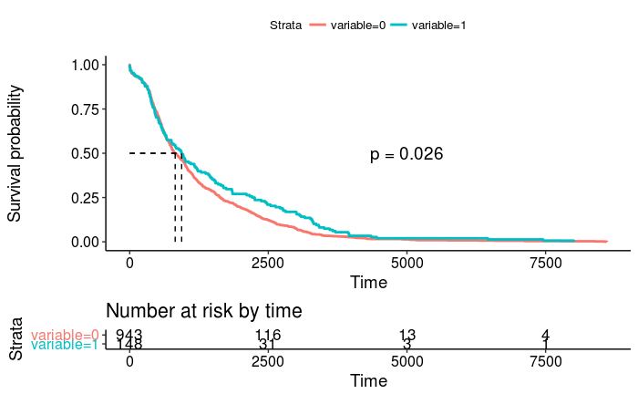

```r
# gene of interest (p53). The $ means end of the line.
ind_gene <- grep("TP53$",rownames(rna.zscore))
variable<- event_rna[ind_gene,]
# survival analysis
s <- survfit(Surv(as.numeric(as.character(clinicalData$new_death)),
                    clinicalData$death_event) ~ variable)
#plot
ggsurvplot(s,pval = T,pval.coord = c(5000,0.5),surv.median.line = "hv",risk.table = TRUE)
```

We can perform unsupervised clustering on the gene expression data to find groups of patients that differ in expression and use the survival data to validate the clusters.

There are a plethora of clustering algorithms implemented in R including k-means,PCA,NMF

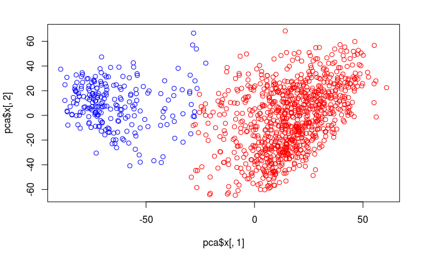

```r
#filter the variance stabilised data by the the most variable genes
rna.vst.tumor<-rna.vst[,t_index]
vars<-apply(rna.vst.tumor,1,var)
topVarGenes<-sort(vars,decreasing = T)[1:1000]
set.seed(42)
#perform k-means clustering to group the patient gene expression into two groups
clusters.kmeans<-kmeans(t(rna.vst.tumor[names(topVarGenes),]),centers = 2)$cluster
#use PCA visualise the high dimentsion data (many genes) and seperate the samples by factors of variance
#could use PCA as a clustering algorithm by defining clusters based on the principal component values.
pca<-prcomp(t(rna.vst.tumor[names(topVarGenes),]))
#plot the first and second principal components
plot(pca$x[,1],pca$x[,2],col=c("red","blue")[clusters.kmeans])
```

Plot the survival curves for the two clusters - do the two subgroups have different survival?

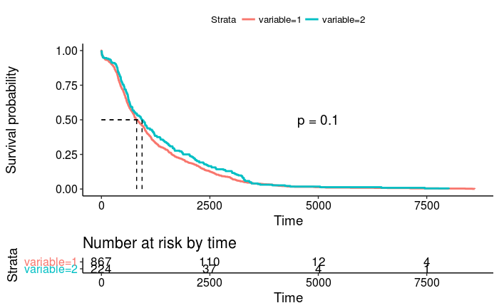

```r
#order to match the clinical data
variable<- clusters.kmeans[ind_tum]
# survival analysis
s <- survfit(Surv(as.numeric(as.character(clinicalData$new_death)),
                    clinicalData$death_event) ~ variable)
#plot
ggsurvplot(s,pval = T,pval.coord = c(5000,0.5),surv.median.line = "hv",risk.table = TRUE)
```

Unsupervised clustering allows us to find subgroups on the basis of gene expression only that we can validate using the survival data. An alternative approach would be to perform supervised clustering where we use the survival data to find subgroups in the gene expression data.

## For you to try

Explore the following questions. Make a record of your code and results in the R notebook.

Download another dataset from TCGA: http://firebrowse.org/  
Choose a cancer and download from the graph on the right:

Clinical_Pick_Tier1 from Clinical  
illuminahiseq_rnaseqv2-RSEM_genes_normalized from mRNASeq

- Rerun the code with the new data
- Choose different genes - can you find any discriminating genes? What genes are mentioned in the literature for the chosen cancer?
- Are there any published gene signatures for the chosen cancer? Modify the code to take several discriminant genes and rerun.
- Modify the code to keep just the up-regulation of the chosen gene as the variable and rerun.
- What genes are important is distinguishing between the two subgroups? Do they make sense it terms of cancer biology?